# Lab 3

Amber Jacobson

October 2, 2017

## Question 1

The Cars93 dataset in the MASS package contains data from 93 cars on sale in the USA in 1993. Randomly select 40 cars as the training dataset and the remaining 53 cars as the test dataset.

```r
library(MASS)
df <- Cars93

set.seed(60)
x <- sample(1:nrow(df), 40)
training <- df[x,]
test <- df[-x, ]
```

```r
training
```

```
##    Manufacturer          Model    Type Min.Price Price Max.Price MPG.city
## 72     Plymouth          Laser  Sporty      11.4  14.4      17.4       23
## 33         Ford          Tempo Compact      10.4  11.3      12.2       22
## 63   Mitsubishi       Diamante Midsize      22.4  26.1      29.9       18
## 91   Volkswagen        Corrado  Sporty      22.9  23.3      23.7       18
## 26        Dodge        Caravan     Van      13.6  19.0      24.4       17
## 9         Buick        Riviera Midsize      26.3  26.3      26.3       19
## 39          Geo          Metro   Small       6.7   8.4      10.0       46
## 77      Pontiac     Bonneville   Large      19.4  24.4      29.4       19
## 4          Audi            100 Midsize      30.8  37.7      44.6       19
## 68   Oldsmobile        Achieva Compact      13.0  13.5      14.0       24
## 85       Toyota         Celica  Sporty      14.2  18.4      22.6       25
## 22     Chrysler       Imperial   Large      29.5  29.5      29.5       20
## 70   Oldsmobile     Silhouette     Van      19.5  19.5      19.5       18
## 28        Dodge        Stealth  Sporty      18.5  25.8      33.1       18
```

[output cut: 190 more lines]

```r
test
```

```
##     Manufacturer        Model    Type Min.Price Price Max.Price MPG.city
## 2          Acura       Legend Midsize      29.2  33.9      38.7       18
## 3           Audi           90 Compact      25.9  29.1      32.3       20
## 5            BMW         535i Midsize      23.7  30.0      36.2       22
## 6          Buick      Century Midsize      14.2  15.7      17.3       22
## 7          Buick      LeSabre   Large      19.9  20.8      21.7       19
## 8          Buick   Roadmaster   Large      22.6  23.7      24.9       16
## 10      Cadillac      DeVille   Large      33.0  34.7      36.3       16
## 11      Cadillac      Seville Midsize      37.5  40.1      42.7       16
## 12     Chevrolet     Cavalier Compact       8.5  13.4      18.3       25
## 13     Chevrolet      Corsica Compact      11.4  11.4      11.4       25
## 14     Chevrolet       Camaro  Sporty      13.4  15.1      16.8       19
## 16     Chevrolet   Lumina_APV     Van      14.7  16.3      18.0       18
## 17     Chevrolet        Astro     Van      14.7  16.6      18.6       15
## 20      Chrylser     Concorde   Large      18.4  18.4      18.4       20
```

[output cut: 255 more lines]

### Question 1A

Save both datasets as csv files. Find out the number of USA and non-USA cars in the training dataset.

```r
write.csv(training, file="training.csv")
write.csv(test, file="test.csv")
```

```r
sum(training$Origin=="non-USA")
```

```
## [1] 16
```

```r
sum(training$Origin=="USA")
```

```
## [1] 24
```

## Question 2

Assume that the probabilities of boy and girl births are 0.515 and 0.485, respectively. Use the sample() function to simulate 10 births and print out the result. How many boys and girls do you get out of 10 births?

```r
births <- sample(c("boy", "girl"), size = 10, replace=TRUE, prob=c(.515, .485))
births
```

```
##  [1] "boy"  "boy"  "boy"  "girl" "girl" "girl" "girl" "boy"  "girl" "boy"
```

```r
table(births)
```

```
## births
##  boy girl
##    5    5
```

### Question 2A

Let’s see what happens when we simulate 10,000 births. How many boys and girls do you get out of 10,000 births?

```r
manybirths <- sample(c("boy", "girl"), size = 10000, replace=TRUE, prob=c(.515, .485))
table(manybirths)
```

```
## manybirths
##  boy girl
## 5085 4915
```

## Question 3

Assume that the probabilities of boy and girl births are 0.515 and 0.485, respectively. What’s the probability of having exactly 3 boys out of 10 births? What’s the probability of having 8 or more boys out of 10 births?

```r
dbinom(3, size=10, prob=.515)
```

```
## [1] 0.1034654
```

```r
pbinom(8, size=10, prob=.515, lower.tail = FALSE)
```

```
## [1] 0.01367209
```

### Question 3A

Plot both the density function and cumulative probability function of the number of boy births out of 10.

**Density function**

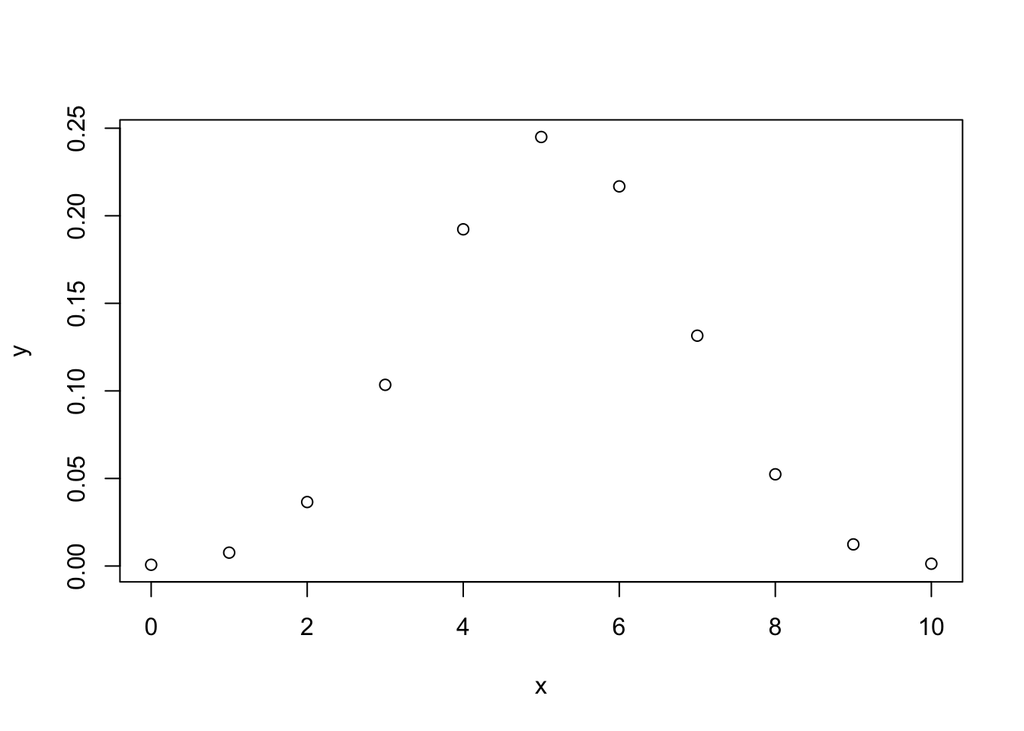

```r
n <- 10
x <- 0:n
y <- dbinom(x, size=10, prob=.515)
plot(x,y)
```

**Cumulative probability function**

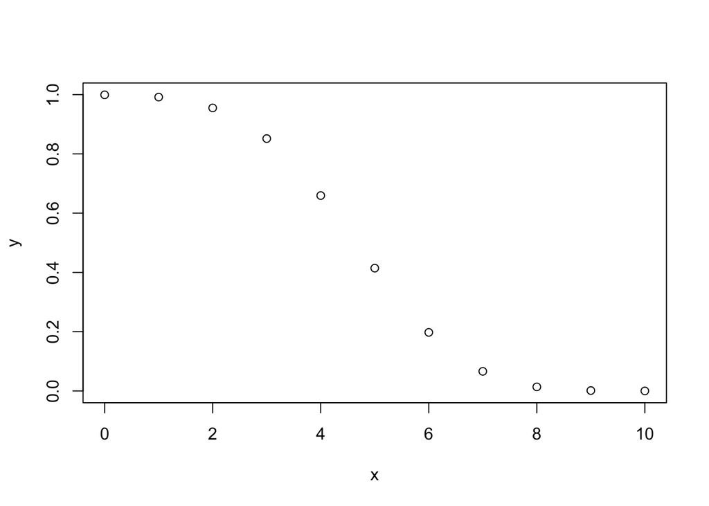

```r
n <- 10
x <- 0:n
y <- pbinom(x, size=10, prob=.515, lower.tail = FALSE)
plot(x,y)
```

## Question 4

If cars arrive randomly at a traffic light at the rate of five every ten seconds:

What the probability that exactly four cars arrive in the next ten seconds?

```r
dbinom(4, size=10, prob=.5)
```

```
## [1] 0.2050781
```

### Question 4A

What’s the probability that more than five cars arrive in the next ten seconds?

```r
pbinom(5, size=10, prob=.5)
```

```
## [1] 0.6230469
```

### Question 4B

Plot the density function of 0-20 cars arriving in the next ten seconds.

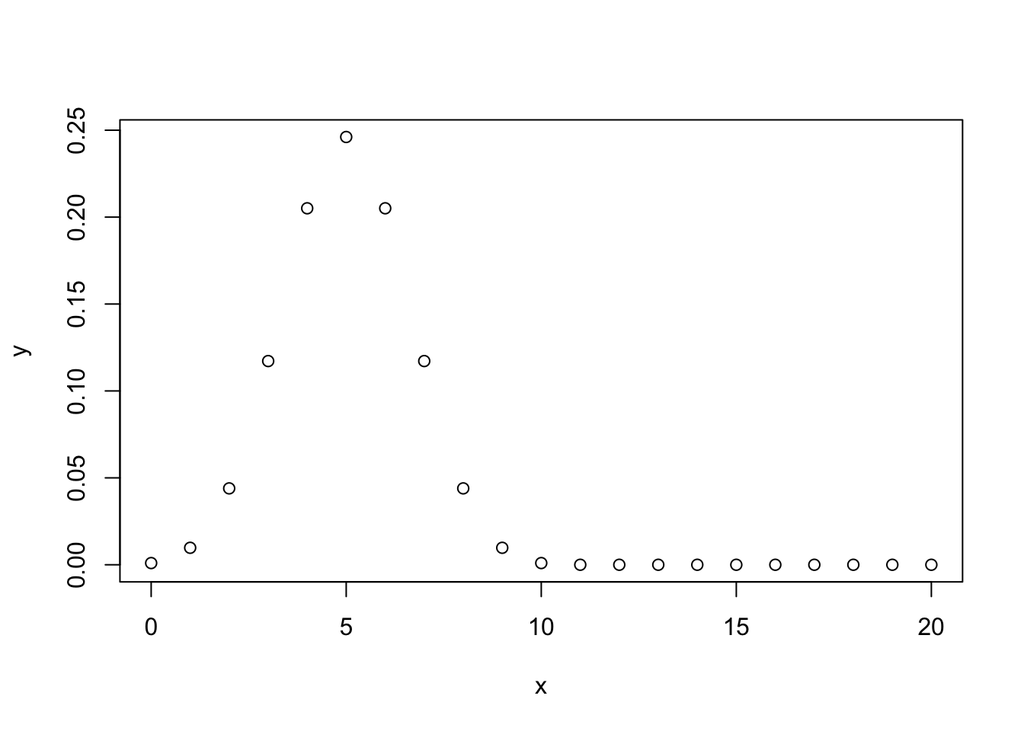

```r
n <- 20
x <- 0:n
y <- dbinom(x, size=10, prob=.5)
plot(x,y)
```